# vivekvajipey_A5

[interactive chart not shown]

The map of PM2.5 in the Bay Area shows the annual mean concentration of PM2.5 in µg/m3 from 2015 to 2017 at the census tract level. The map of asthma in the Bay Area shows the age-adjusted rate of emergency department visits for asthma per 10,000 (averaged over 2015-2017). Two areas that stick out as facing from both high concentrations of PM2.5 and high rates of asthma-caused ED visits are Vallejo and Anitoch.

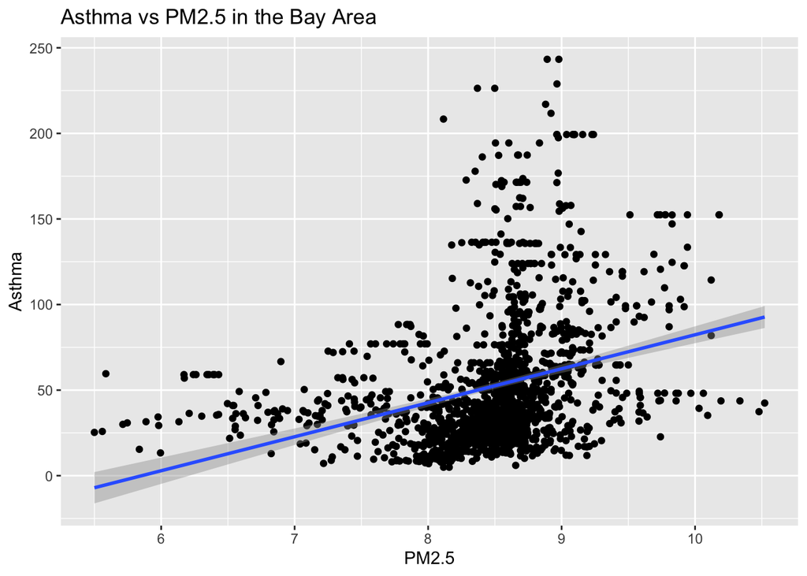

The line of best fit does not seem to fit the data very well, due to the rather jumbled and unevenly distributed nature of the data points. Between 8 and 9 µg/m^3, there is a large cluster of points that greatly exceed the asthma prevalence of the best fit line.

```
##
## Call:
## lm(formula = Asthma ~ PM2.5, data = ces4_bay_pm25_asthma)
##
## Residuals:
##    Min     1Q Median     3Q    Max
## -54.47 -25.89  -9.61  12.94 182.95
##
## Coefficients:
##             Estimate Std. Error t value Pr(>|t|)
## (Intercept) -116.278     13.040  -8.917   <2e-16 ***
## PM2.5         19.862      1.534  12.950   <2e-16 ***
## ---
## Signif. codes:  0 '***' 0.001 '**' 0.01 '*' 0.05 '.' 0.1 ' ' 1
##
## Residual standard error: 37.49 on 1578 degrees of freedom
##   (1 observation deleted due to missingness)
## Multiple R-squared:  0.09606,    Adjusted R-squared:  0.09549
## F-statistic: 167.7 on 1 and 1578 DF,  p-value: < 2.2e-16
```

Based on this linear regression model, an increase of 1 µg/m3 of annual mean concentration of PM2.5 is correlated with an increase of 19.862 emergency department visits for asthma per 10,000. The standard error of this slope value is 1.534.

The r-squared value is approximately 0.096, indicating that the variation in annual mean PM2.5 concentrations explains 9.6% of the variation in asthma-caused emergency department vists.

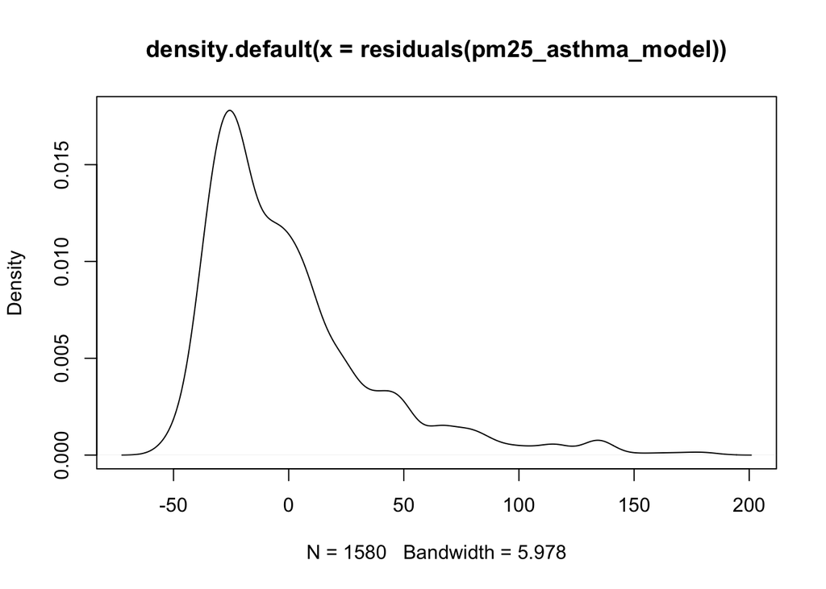

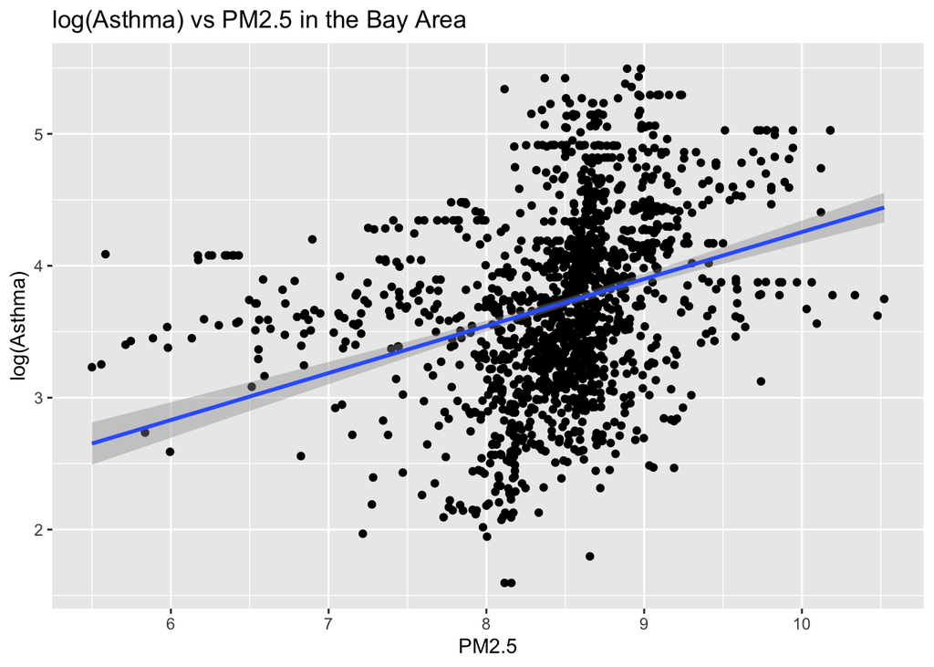

This scatter plot also exhibits the vertical cluster of data points between 8 and 9 µg/m^3, however compared to the linear model, this log model seems to fit the data points more closely.

```
##
## Call:
## lm(formula = log(Asthma) ~ PM2.5, data = ces4_bay_pm25_asthma)
##
## Residuals:
##      Min       1Q   Median       3Q      Max
## -2.00402 -0.46479  0.03313  0.42298  1.75525
##
## Coefficients:
##             Estimate Std. Error t value Pr(>|t|)
## (Intercept)  0.69234    0.22840   3.031  0.00248 **
## PM2.5        0.35633    0.02686  13.264  < 2e-16 ***
## ---
## Signif. codes:  0 '***' 0.001 '**' 0.01 '*' 0.05 '.' 0.1 ' ' 1
##
## Residual standard error: 0.6566 on 1578 degrees of freedom
##   (1 observation deleted due to missingness)
## Multiple R-squared:  0.1003, Adjusted R-squared:  0.09974
## F-statistic: 175.9 on 1 and 1578 DF,  p-value: < 2.2e-16
```

The r-squared value is approximately 0.10, indicating that the variation in annual mean PM2.5 concentrations explains 10% of the variation in asthma-caused emergency department vists.

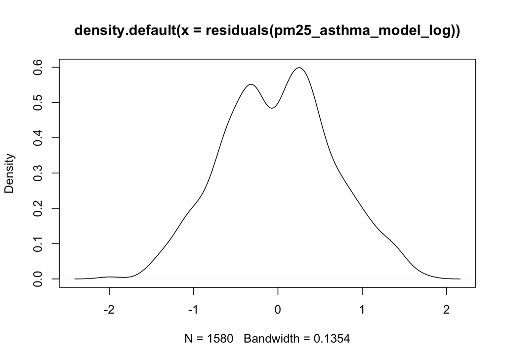

This distribution of residuals is significantly more normal than that of the linear model, with the mean being very close to zero and the overall curve being neither skewed right nor left. The clear distinction between the curve and a standard normal distribution is the dip at the mean with two peaks to the left and right.